# Slides

◔◑◕

## IPySlides 5.6.0 Documentation

### Creating slides with IPySlides

Abdul Saboor<sup>1</sup>

Jun 18, 2025

<sup>1</sup>My University is somewhere in the middle of nowhere

IPySlides Documentation

## Table of contents

1. Introduction Introduction
2. Adding Slides and Content Adding Slides and Content
3. Layout and Theme Settings Layout and Theme Settings
4. Useful Functions for Rich Content Useful Functions for Rich Content
5. Loading from File/Exporting to HTML Loading from File/Exporting to HTML
6. Advanced Functionality Advanced Functionality
7. Presentation Code Presentation Code

### This is summary of current section

Oh we can use inline columns

Column A

Column B

here and what not!

Markdown

````
```multicol .block-green
toc[True]`## Table of contents`
+++
Extra content for current section which is on right
```
````

1

IPySlides Documentation

# Main App

**Slides**

Interactive Slides in IPython Notebook. Only one instance can exist. `settings` are passed to `Slides.settings()` if you like to set during initialization.

To suppress unwanted print from other libraries/functions, use:

Python

```
with slides.suppress_stdout():
    some_function_that_prints() # This will not be printed
    print('This will not be printed either')
    display('Something') # This will be printed
```

The traitlets callables under settings returns settings back to enable chaining without extra typing, like `Slides.settings.logo().layout()...` .

- Use `Slides.instance()` class method to keep older settings. `Slides()` apply default settings every time.
- Run `slides.demo()` to see a demo of some features.
- Run `slides.docs()` to see documentation.
- Instructions in left settings panel are always on your fingertips.
- Creating slides in a batch using `Slides.create` is much faster than adding them one by one.
- In JupyterLab, right click on the slides and select `Create New View for Output` for optimized display.
- To jump to source cell and back to slides by clicking buttons, set `Windowing mode` in Notebook settings to `defer` or `none`.
- See `Slides.xmd_syntax` for extended markdown syntax, especially variables formatting.
- Inside python scripts or for encapsulation, use `Slides.fmt` to pick variables from local scope.

`Slides` can be indexed same way as list for sorted final indices. For indexing slides with given number, use comma as `Slides[number,] -> Slide` or access many via list as `Slides[[n1,n2,..]] -> tuple[Slide]`. Use indexing with given number to apply persistent effects such as CSS.

### Jump between slides

Slides.**goto_button**

Initialize a button to jump to given target slide when clicked. `text` is the text to be displayed on button. `kwargs` are passed to `ipywidgets.Button` function.

- Pass to write command or use `.display()` method to display button in a slide.
- Use `.set_target()` method under target slide.
- `goto_button` is converted to a link in exported slides that can be clicked to jump to slide.
- You can use `.set_target()` on a previous slides and `.display()` on a later slide to create a link that jumps backwards.

2

IPySlides Documentation

## Adding Slides

Besides function below, you can add slides with `%%slide number [-m]` magic as well.

Slides.**build**

Build slides with a single unified command in three ways:

1. `slides.build(number, callable)` to create a slide from a `callable(slide)` immediately, e.g. `lambda s: slides.write(1,2,3)` or as a decorator.
   - Docstring of callable (if any) is parsed as markdown before calling function.
2. `with slides.build(number):` creates single slide. Equivalent to `%%slide number` magic.
   - Use `fsep()` from top import or `Slides.fsep()` to split content into frames.
   - Use `for item in fsep.iter(iterable):` block to automatically add frame separator.
   - Use `fsep(True)`/`fsep.iter(...,stack=True)` to join content of frames incrementally.
3. `slides.build(number, str | fmt)` creates many slides with markdown content. Equivalent to `%%slide number -m` magic in case of one slide.
   - Frames separator is double dashes `--` and slides separator is triple dashes `---`. Same applies to `Slides.sync_with_file` too.
   - Use `%++` to join content of frames incrementally.
   - Markdown `multicol` before `--` creates incremental columns if `%++` is provided.
   - See `slides.xmd_syntax` for extended markdown usage.
   - To debug markdown content, use EOF on its own line to keep editing and clearing errors. Same applies to `Slides.sync_with_file` too.
   - In case of str input, varaiables such as %{var} can be updated by creating/updating `var` in notebook.
   - In case of `fmt(str, **kwargs)`, varaiables are picked from `kwargs` or local scope and can't be changed later. Useful in python scripts.
- In all cases, `number` could be used as `-1`.
- Use yoffet`integer in px` in markdown or `Slides.this.yoffset(integer)` to make all frames align vertically to avoid jumps in increments.
- You can use `build_(...)` (with underscore at end) in python file instead of `build(-1,...)`.

Slides.**sync_with_file**

Auto update slides when content of markdown file changes. You can stop syncing using `Slides.unsync` function. interval is in milliseconds, 500 ms default. Read `Slides.build` docs about content of file.

The variables inserted in file content are used from top scope.

To debug a linked file, use EOF on its own line to keep editing and clearing errors.

3

IPySlides Documentation

## Important Methods on Slide

Use slide handle or `Slides[number,]` to apply these methods becuase index can change on new builds.

Slide.**yoffset**

Set yoffset (in perect) for frames to have equal height in incremental content.

Slide.**set_animation**

Set animation of this slide. Provide None if need to stop animation. Use main_all and frame to set animation to all slides.

Slide.**set_bg_image**

Adds background image to this slide. `src` can be a url or a local image path or an svg str. filter is a CSS filter like blur(5px), grayscale() etc.

This function enables you to add a slide purely with an image, possibly with `opacity=1` and `contain = True`.

Slide.**update_display**

Update display of this slides including reloading citations, widgets etc.

Slide.**get_source**

Return source code of this slide, markdwon or python or None if no source exists. kwargs are passed to `Slides.code.from_string`.

Slide.**show**

Show this slide in cell.

Slide.**set_css**

Attributes at the root level of the dictionary are only picked if they are related to background. Each call will reset previous call if props given explicitly, otherwise not.

- See `Slides.css_syntax` for information on how to write CSS dictionary.
- Unlike `slides.html('style',props)`, you can set CSS variables at top level here including theme variables `--fg[1,2,3]-color`,`--bg[1,2,3]-color` and `--[accent, pointer]-color` to tweek appearance of individual or all slides.

CSS is formatted using a `props` nested dictionary to simplify the process. There are few special rules in `props`:

- All nested selectors are joined with space, so `'.A': {'.B': ... }` becomes `.A .B {...}` in CSS.
- A '^' in start of a selector joins to parent selector without space, so `'.A': {'^:hover': ...}` becomes `.A:hover {...}` in CSS. You can also use `'.A:hover'` directly but it will restrict other nested keys to hover only.
- A list/tuple of values for a key in dict generates CSS fallback, so `'.A': {'font-size': ('20px','2em')}` becomes `.A {font-size: 20px; font-size: 2em;}` in CSS.

Read about specificity of CSS selectors [here](https://developer.mozilla.org/en-US/docs/Web/CSS/Specificity).

Python

```
props = {
  ".A": {
    "z-index": "2",
    ".B": {
      "font-size": [
        "24px",
        "2em"
      ],
      "^:hover": {
        "opacity": "1"
      }
    },
    "> h1": {
      "padding": "0",
      "@media screen and (min-width: 650px)": {
        "padding": "2em"
      }
    },
    ".C p": {
      "font-size": "14px"
    }
  },
  ".D": {
    "transform": "translate(-2px,1px)",
    "^, h1": {
      "background": "red",
      "span, i": {
        "color": "whitemoke",
        "@keyframes animation-name": {
          "from": {
            "opacity": 0
          },
          "to": {
            "opacity": 1
          }
        }
      }
    }
  }
}
```

Output of `html('style',props)`, `set_css(props)` etc. functions. Top selector would be different based on where it is called.

CSS

```
<style>
.SlideArea .A {
    z-index : 2;
}
.SlideArea .A .B {
    font-size : 24px;
    font-size : 2em;
}
.SlideArea .A .B:hover {
    opacity : 1;
}
.SlideArea .A > h1 {
    padding : 0;
}
@media screen and (min-width: 650px) {
    .SlideArea .A > h1 {
        padding : 2em;
    }
}
.SlideArea .A .C p {
    font-size : 14px;
}
.SlideArea .D {
    transform : translate(-2px,1px);
}
.SlideArea .D,
.SlideArea .D  h1 {
    background : red;
}
.SlideArea .D span,
.SlideArea .D  i,
.SlideArea .D h1 span,
.SlideArea .D h1  i {
    color : whitemoke;
}
@keyframes animation-name {
    from {
        opacity : 0;
    }
    to {
        opacity : 1;
    }
}
</style>
```

4

IPySlides Documentation

Python

```
# self is in scope, auto picked, also fmt can be parsed on display
display(self.fmt('%{self.version!r} %{self.xmd_syntax}'))
```

'5.6.0'

**Extended Markdown**

Extended syntax for markdown is constructed to support almost full presentation from Markdown.

**Slides-specific syntax**

**Notes**

notes`This is slide notes` to add notes to current slide

**Slides & Frames Separators**

Triple dashes `---` is used to split text in slides inside markdown content of `Slides.build` function or markdown file. Double dashes `--` is used to split text in frames. Alongwith this `%++` can be used to increment text on framed slide.

**Citations**

cite`key` to add citation to current slide. citations are automatically added in suitable place and should be set once using `Slides.set_citations` function. With citations mode set as 'footnote', you can add refs`ncol_refs` to add citations anywhere on slide. If `ncol_refs` is not given, it will be picked from layout settings.

**Sections & TOC**

section`content` to add a section that will appear in the table of contents. toc`Table of content header text` to add a table of contents. See `Slides.docs()` for creating a `TOC` accompanied by section summary.

**General syntax**

- Variables can be shown as widgets or replaced with their HTML value (if no other formatting given) using %{variable} (or legacy `{variable}`) (should be single curly braces pair wrapped by backticks after other formattings done) syntax. If a format_spec/conversion is provided like %{variable:format_spec} or %{variable!conversion}, that will take preference.
- A special formatting %{variable:nb} is added (`version >= 4.5`) to display objects inside markdown as they are displayed in a Notebook cell. Custom objects serialized with `Slides.serializer` or serialized by `ipyslides` should be displayed without `:nb` whenever possible to appear in correct place in all contexts. e.g. a matplotlib's figure `fig` as shown in `%{fig:nb}` will only capture text representation inplace and actual figure will be shown at end, while `%{fig}` will be shown exactly in place.
- Variables are automatically updated in markdown when changed in Notebook for slides built purely from markdown.
  - You can also use `Slide[number,].rebuild(**kwargs)` to force update variables if some error happens. This is useful for setting unique values of a variable on each slide.
  - Markdown enclosed in `fmt(content, **vars)` will not expose encapsulated `vars` for updates later, like static stuff but useful inside python scripts to pick local scope variable.
  - In summary, variables are resolved by scope in the prefrence `rebuild > __main__`. Outer scope variables are overwritter by inner scope variables.
- Use unique variable names on each slide to avoid accidental overwriting during update.
- Varibales used as attributes like `%{var.attr}` and indexing like `%{var[0]}`/`%{var["key"]}` will be update only if `var` itself is changed.

%{variable:nb} breaks the DOM flow, e.g. if you use it inside heading, you will see two headings above and below it with splitted text. Its fine to use at end or start or inside paragraph.

- Widgets behave same with or without `:nb` format spec.
- Formatting is done using `str.format` method, so f-string like literal expressions are not supported, but you don't need to supply variables, just enclose text in `Slides.fmt`.
- Variables are substituted from top level scope (Notebook's `locals()`/`globals()`). To use variables from a nested scope, use `Slides.fmt`.
- A syntax func`?Markdown?` will be converted to func`Parsed HTML` in markdown. Useful to nest special syntax.
- Escape a backtick with \, i.e. \\` → `. In Python >=3.12, you need to make escape strings raw, including the use of $ \LaTeX $ and re module.
- include`markdown_file.md` to include a file in markdown format.
- Two side by side columns can be added inline using ||[width optionally here in 1-99] Column A || Column B || sytnax.
- Block multicolumns are made using follwong syntax, column separator is triple plus `+++`:

Markdown

````
```multicol widthA widthB .class1.class2
Column A
+++
Column B
```
````

- Definition list syntax:

```
Item 1 Header
: Item 1 details

Item 1 Header
: Item 1 details
```

👉

**Item 1 Header**

Item 1 details

**Item 1 Header**

Item 1 details

- Code blocks syntax highlighting. (there is an inline highlight syntax as well hl`code`)

Python

```
print('Hello, I was highlighted from a code block!')
```

- A whole block of markdown can be CSS-classed using syntax

```
::: block-yellow
    Some **bold text**
```

👉

Some **bold text**

Note

Above block syntax is enabled using customblocks which is added by default and can be used to build nested html blocks.

- You can use `Slides.extender` to extend additional syntax using Markdown extensions such as [markdown extensions](https://python-markdown.github.io/extensions/) and [PyMdown-Extensions](https://facelessuser.github.io/pymdown-extensions/).
- These markdown extensions are inluded by default `['tables', 'footnotes', 'attr_list', 'md_in_html', 'customblocks', 'def_list']`.
- You can serialize custom python objects to HTML using `Slides.serializer` function. Having a `__format__` method in your class enables to use {obj} syntax in python formatting and %{obj} in extended Markdown.
- Other options (that can also take extra args [python code as strings] as func[arg1,x=2,y=A]`arg0`) include:
  - alert`text`,
  - color`text`,
  - sub`text`,
  - sup`text`,
  - hl`inline code highlight. Accepts langauge as keywoard.`,
  - today`format_spec like %b-%d-%Y`,
  - textbox`text`,
  - clip`filename. Paste clipboard image`,
  - image`path/src or clip:filename`,
  - raw`text`,
  - svg`path/src`,
  - iframe`src`,
  - details`text`,
  - styled`style objects with CSS classes and inline styles`,
  - zoomable`zoom a block of html when hovered`,
  - center`text or %{variable}`

5

IPySlides Documentation

## Adding Content

Besides functions below, you can add content to slides with `%%xmd`,`%xmd` as well.

Slides.**write**

Write `objs` to slides in columns. To create rows in a column, wrap objects in a list or tuple.  
You can optionally specify `widths` as a list of percentages for each column. `css_class` can have multiple classes separated by space, works only for multiple columns.

Write any object that can be displayed in a cell with some additional features:

- Strings will be parsed as as extended markdown that can have citations/python code blocks/Javascript etc.
- Display another function to capture its output in order using `Slides.hold(func,...)`. Only body of the function will be displayed/printed. Return value will be ignored.
- Dispaly IPython widgets such as `ipywidgets` or `ipyvolume` by passing them directly.
- Display Axes/Figure form libraries such as `matplotlib`, `plotly` `altair`, `bokeh` etc. by passing them directly.
- Display source code of functions/classes/modules or other languages by passing them directly or using `Slides.code` API.
- Use `Slides.alt` function to display obj/widget on slides and alternative content/screenshot in exported slides.
- Use `Slides.clip` to add screenshots from clipboard.
- `ipywidgets.[HTML, Output, Box]` and their subclasses will be displayed as `Slides.alt(html_converter_func, widget)`. The value of exported HTML will be most recent.
- Other options include but not limited to:
  - Output of functions in `ipyslides.utils` module that are also linked to `Slides` object.
  - PIL images, SVGs etc.
  - IPython display objects such as Image, SVG, HTML, Audio, Video, YouTubeVideo, IFrame, Latex, Markdown, JSON, Javascript, etc.
  - Any object that has a `_repr_html_` method, you can create one for your own objects/third party objects by:
    - `Slides.serializer` API. IPython's `display` automatically takes care of such objects on export to html.
    - `IPython.core.formatters` API for third party libraries.

Note

- Use `Slides.frozen` to avoid display formatting and markdown parsing over objects in `write` and for some kind of objects in `display` too.
- `write` is a robust command that can handle most of the cases. If nothing works, `repr(obj)` will be displayed.
- You can avoid `repr(obj)` by `Slides.hold(func, ...)` e.g. `Slides.hold(plt.show)`. This can also be used to delay display until it is captured in a column.
- You can use `display(obj, metadata = {'text/html': 'html repr by user'})` for any object to display object as it is and export its HTML representation in metadata.
- A single string passed to `write` is equivalent to `parse` command.
- You can add mini columns inside a column by markdown syntax or `Slides.cols`, but content type is limited in that case.

Slides.**parse**

Parse extended markdown and display immediately. If you need output html, use `returns = True` but that won't display variables.

**Example**

Markdown

````
# Normal Markdown
```multicol 40 60
# First column is 40% width
If 40 60 was not given, all columns will be of equal width, this paragraph will be inside info block due to class at bottom
{.info}
+++
# Second column is 60% wide
This \%{var_name} (or legacy \`{var_name}\`) can be substituted with `fmt` function or from notebook if whole slide is built with markdown.
```

```python
# This will not be executed, only shown
```
|| Inline-column A || Inline-column B ||
````

- Each block can have class names (speparated with space or .) after all other options such as `python .friendly` or `multicol .Sucess.info`.
  - For example, `python .friendly` will be highlighted with friendly theme from pygments.
  - Pygments themes, however, are not supported with `multicol`.
  - You need to write and display CSS for a custom class.
- The block with `::: class_type` syntax accepts extra classes in quotes, for example `::: multicol "Success" "info"`.
- There are special CSS classes `jupyter-only` and `export-only` that control appearance of content in different modes.

Nested blocks are not supported.

- Find special syntax to be used in markdown by `Slides.xmd_syntax`.
- Use `Slides.extender` or `ipyslides.xmd.extender` to add [markdown extensions](https://python-markdown.github.io/extensions/).

Slides.**clip**

Save image from clipboard to file with a given quality when you paste in given area on slides. Pasting UI is automatically enabled and can be disabled in settings panel. On next run, it loads from saved file under `Slides.clips_dir`.

If `obj` is given (any object), that is directly shown on slides without any parsing and pasted image is exported. If no `obj` is passed, both slides and exported HTML shares same image view.

On each paste, existing image is overwritten and stays persistent for later use. You can use these clips in other places with `Slides.image("clip:filename")` as well.

`Slides.alt('clip:test.png', obj)` is same as `display(obj);Slides.clip('test.png', export_only=True)`.

If you have an HTML serialization function for a widget, pass it directly to `write` or use `alt(func, widget)` instead. That will save you the hassel of copy pasting screenshots. `ipywidgets`'s `HTML`, `Box` and `Output` widgets and their subclasses directly give html representation if used inside `write` command.

**kwargs are passed to `Slides.image` function.

On Linux, you need xclip or wl-paste installed.

6

IPySlides Documentation

## Adding Speaker Notes

Skip to Dynamic Content

This is experimental feature, and may not work as expected.

Slides.notes.**display**

Slides.notes.**insert**

Add notes to current slide. Content could be any object except javascript and interactive widgets.

In markdown, you can use notes`notes content`.

7

IPySlides Documentation

## Displaying Source Code

Slides.code.**cast**

Create source code object from file, text or callable. `kwargs` are passed to `ipyslides.formatter.highlight`.

Slides.code.**context**

Execute and displays source code in the context manager. `kwargs` are passed to `ipyslides.formatter.highlight` function. Useful when source is written inside context manager itself. If `returns` is False (by default), then source is displayed before the output of code. Otherwise you can assign the source to a variable and display it later anywhere.

**Usage**:

Python

```
with source.context(returns = True) as s:
    do_something()
    write(s) # or s.display(), write(s)

#s.raw, s.value are accesible attributes.
#s.focus_lines, s.show_lines are methods that are used to show selective lines.
```

Slides.code.**from_callable**

Returns source object from a given callable [class,function,module,method etc.] with `show_lines` and `focus_lines` methods. `kwargs` are passed to `ipyslides.formatter.highlight`

Slides.code.**from_file**

Returns source object with `show_lines` and `focus_lines` methods. `name` is alternate used name for language.  
`kwargs` are passed to `ipyslides.formatter.highlight`.

It tries to auto detect lanaguage from filename extension, if `language` is not given.

Slides.code.**from_string**

Creates source object from string. `name` is alternate used name for language. `kwargs` are passed to `ipyslides.formatter.highlight`.

8

IPySlides Documentation

### Contents

1. Introduction Introduction
2. Adding Slides and Content Adding Slides and Content
3. Layout and Theme Settings Layout and Theme Settings
4. Useful Functions for Rich Content Useful Functions for Rich Content
5. Loading from File/Exporting to HTML Loading from File/Exporting to HTML
6. Advanced Functionality Advanced Functionality
7. Presentation Code Presentation Code

9

IPySlides Documentation

## Layout and Theme Settings

Slides.**Settings**

Apply settings to slides programatically. Fewer settings are available as widgets.

Settings can be nested or individual attributes as set as well. For example:

Python

```
Slides.settings(layout = {"aspect": 16/10}) # Top
Slides.settings.layout(aspect = 16/10) # Individual
Slides.settings.layout.aspect = 16/10  # Attribute
```

All settings calls including top level returns settings instance to apply method chaining. e.g. `Slides.settings.layout(aspect = 16/10).footer(text="ABC").logo(...)`.

Slides.Settings.**Code**

Set code block styles. background and color may be needed for some styles.

Slides.Settings.**Fonts**

Set fonts of text and code and size.

Slides.Settings.**Footer**

Set footer attributes of slides.

Slides.Settings.**Layout**

Set layout of slides.

Slides.Settings.**Logo**

Set logo for all slides.

Slides.Settings.**Theme**

Set theme value. colors and code have their own nested traits.

Slides.Settings.**Toggle**

Toggle ON/OFF checks in settings panel.

10

IPySlides Documentation

## Useful Functions for Rich Content

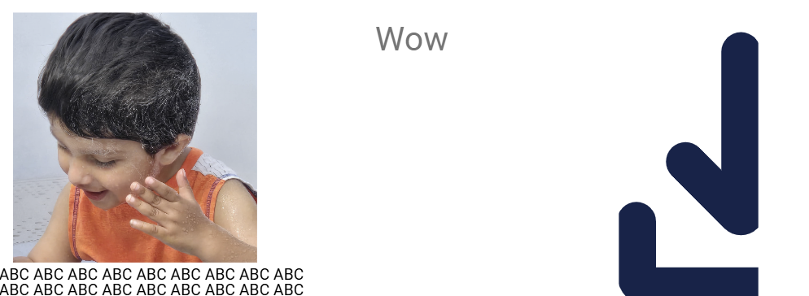

clipboard image

Markdown

```
clip[caption='clipboard image']`test.png`
```

Slides.**clip**

Save image from clipboard to file with a given quality when you paste in given area on slides. Pasting UI is automatically enabled and can be disabled in settings panel. On next run, it loads from saved file under `Slides.clips_dir`.

If `obj` is given (any object), that is directly shown on slides without any parsing and pasted image is exported. If no `obj` is passed, both slides and exported HTML shares same image view.

On each paste, existing image is overwritten and stays persistent for later use. You can use these clips in other places with `Slides.image("clip:filename")` as well.

`Slides.alt('clip:test.png', obj)` is same as `display(obj);Slides.clip('test.png', export_only=True)`.

If you have an HTML serialization function for a widget, pass it directly to `write` or use `alt(func, widget)` instead. That will save you the hassel of copy pasting screenshots. `ipywidgets`'s `HTML`, `Box` and `Output` widgets and their subclasses directly give html representation if used inside `write` command.

**kwargs are passed to `Slides.image` function.

On Linux, you need xclip or wl-paste installed.

Slides.**AnimationSlider**

This is a simple slider widget that can be used to control the animation with an observer function.

You need to provide parameters like `nframes` and `interval` (milliseconds) to control the animation. The `value` trait can be observed to get the current frame index. The `cyclic` trait can be set to `True` to make the animation cyclic and only works when loop mode is ON.

Python

```
from plotly.graph_objects import FigureWidget

fig = FigureWidget()
fig.add_scatter(y=[1, 2, 3, 4, 5])
widget = slides.AnimationSlider() # assuming slides is the instance of Slides app

def on_change(change):
    value = change['new']
    fig.data[0].color = f'rgb({int(value/widget.nframes*100)}, 100, 100)' # change color based on frame index

widget.observe(on_change, names='value')
display(widget, fig) # display it in the notebook
```

This widget can be passed to `ipywidgets.interactive` as keyword argument to create a dynamic control for the animation.

Python

```
from ipywidgets import interact

@interact(frame=widget)
def show_frame(frame):
    print(frame)
```

Slides.**alert**

Alerts text!

Slides.**block**

Format a block like in LATEX beamer with `objs` in columns and immediately display it. Format rows by given an obj as list of objects.

- Block is automatically displayed and returns nothing.
- Available functions include: `block_<red,green,blue,yellow,cyan,magenta,gray>`.
- You can create blocks just by CSS classes in markdown as {.block}, {.block-red}, {.block-green}, etc.
- See documentation of `write` command for details of `objs` and `widths`.

Slides.**bokeh2html**

Write bokeh figure as HTML string to use in `ipyslide.utils.write`. **Parameters**

- bokeh_fig : Bokeh figure instance.
- title : Title for figure.

Slides.**bullets**

A powerful bullet list. `iterable` could be list of anything that you can pass to `write` command.  
`marker` could be a unicode charcter or string, only effects unordered list.

Slides.**color**

Colors text, `fg` and `bg` should be valid CSS colors

Slides.**cols**

Returns HTML containing multiple columns of given widths. This alongwith `rows` can create grid.

Slides.**details**

Show/Hide Content in collapsed html.

Slides.**doc**

Returns documentation of an `obj`. You can prepend a class/module name. members is True/List of attributes to show doc of.

Slides.**error**

Add error without breaking execution.

Slides.**fmt**

Markdown string wrapper that will be parsed with given kwargs lazily. If markdown contains variables not in kwargs, it will try to resolve them from local/global namespace and raise error if name is nowhere. Use inside python scripts when creating slides. In notebook, variables are automatically resolved, although you can still use it there.

Being as last expression of notebook cell or using self.parse() will parse markdown content.

Slides.**frozen**

Display object as it it and export metadata if not str. A frozen object may not appear in exported html if metadata is not given.

Returned object has a display method, or can be directly passed to display/write commands.

Slides.**highlight**

Highlight code (any python object that has a source or str of code) with given language and style.

- style only works if css_class is given.
- If css_class is given and matches any of `pygments.styles.get_all_styles()`, then style will be applied immediately.
- color is used for text color as some themes dont provide text color.
- height is max-height of code block, it does not expand more than code itself.

If you want plain inline highlight, use `Slides.oripyslides.utils.hl`.

Slides.**html**

Returns html node with given children and node attributes like style, id etc. If an ttribute needs '-' in its name, replace it with '_'.  
`tag` can be any valid html tag name. A `tag` that ends with `/` will be self closing e.g. `hr/` will be `<hr/>`. Empty tag gives unwrapped children. `children` expects:

- If None, returns node such as 'image' ->

[figure not shown]

  and 'image/' ->

[figure not shown]

- str: A string to be added as node's text content.
- list/tuple of [objects]: A list of objects that will be parsed and added as child nodes. Widgets are not supported.
- dict if tag is 'style', this will only be exported to HTML if called under slide builder, use `slides[number,].set_css` otherwise. See `Slides.css_syntax` to learn about requirements of styles in dict.

Example:

Python

```
html('img',src='ir_uv.jpg') #Returns IPython.display.HTML("<img src='ir_uv.jpg'></img>") and displas image if last line in notebook's cell.
```

To keep an image persistently embeded, use `ipyslides.utils.imge` function instead of just an html tag.

Slides.**iframe**

Display `src` in an iframe. `kwrags` are passed to IPython.display.IFrame

Slides.**image**

Displays PNG/JPEG files or image data etc, `kwrags` are passed to IPython.display.Image. `crop` is a tuple of (left, top, right, bottom) in percentage of image size to crop the image. `css_props` are applied to `figure` element, so you can control top layout and nested img tag. You can provide following to `data` parameter:

- An opened PIL image. Useful for image operations and then direct writing to slides.
- A file path to image file.
- A url to image file.
- A str/bytes object containing image data.
- A str like "clip:image.png" will load an image saved using `Slides.clip('image.png')`.

**Returns** an `IMG` object which can be exported to other formats (if possible):

- `IMG.to_pil()` returns `PIL.Image` or None.
- `IMG.to_numpy()` returns image data as numpy array for use in plotting libraries or None.

Slides.**notify**

Send inside notifications for user to know whats happened on some button click. Send 'x' in content to clear previous notification immediately.

Slides.**plt2html**

Write matplotib figure as HTML string to use in `ipyslide.utils.write`. **Parameters**

- plt_fig : Matplotlib's figure instance, auto picks as well.
- transparent: True of False for fig background.
- width : CSS style width. Default is figsize.
- caption : Caption for figure.
- crop : Crop SVG to given box in fraction 0-1 as tuple of (left, top, right, bottom).

Slides.**raw**

Keep shape of text as it is (but apply dedent), preserving whitespaces as well.

Slides.**rows**

Creates single compact object instead of publishing multiple display data. Create grid using `cols` as children.

Slides.**set_dir**

Context manager to set working directory to given path and return to previous working directory when done.

Slides.**sig**

Returns signature of a callable. You can prepend a class/module name.

Slides.**styled**

Add a class to a given object, whether a widget or html/IPYthon object. CSS inline style properties should be given with names including '-' replaced with '_' but values should not. Only a subset of inline properties take effect if obj is a widget.

Objects other than widgets will be wrapped in a 'div' tag. Use `html` function if you need more flexibility.

Slides.**suppress_output**

Suppress output of a block of code. If `stdout` is False, only display data is suppressed.

Slides.**suppress_stdout**

Suppress stdout in a block of code, especially unwanted print from functions in other modules.

Slides.**svg**

Display svg file or svg string/bytes with additional customizations. `crop` is a tuple of (left, top, right, bottom) in percentage of image size to crop the image. `css_props` are applied to `figure` element, so you can control top layout and nested svg tag. `kwrags` are passed to IPython.display.SVG. You can provide url/string/bytes/filepath for svg.

Slides.**table**

Creates a table of given data like DataFrame, but with rich elements. `data` should be a 2D matrix-like. `headers` is a list of column names. `widths` is a list of widths for each column.

Example:

Python

```
import pandas as pd
df = pd.DataFrame({'A': [1,2,3], 'B': [4,5,6]})
slides.table(df.values, headers=df.columns, widths=[1,2])

slides.table([[1,2,3],[4,5,6]], headers=['A','B','C'], widths=[1,2,3])
```

Slides.**textbox**

Formats text in a box for writing e.g. inline refrences. `css_props` are applied to box and `-` should be `_` like `font-size` -> `font_size`. `text` is not parsed to general markdown i.e. only bold italic etc. applied, so if need markdown, parse it to html before. You can have common CSS for all textboxes using class `text-box`.

Slides.**today**

Returns today's date in given format.

Slides.**vspace**

Returns html node with given height in `em`.

Slides.**zoomable**

Wraps a given obj in a parent with 'zoom-child' class or add 'zoom-self' to widget, whether a widget or html/IPYthon object

11

IPySlides Documentation

## Citations and Sections

Use syntax cite`key` to add citations which should be already set by `Slides.set_citations(data, mode)` method. Citations are written on suitable place according to given mode. Number of columns in citations are determined by `Slides.settings.layout(..., ncol_refs = int)`. <sup>1</sup>

Add sections in slides to separate content by section`text`. Corresponding table of contents can be added with toc`title`.

Slides.**set_citations**

Set citations from dictionary or file that should be a JSON file with citations keys and values, key should be cited in markdown as cite`key`. `mode` for citations should be one of ['inline', 'footnote']. Number of columns in citations are determined by `Slides.settings.layout(..., ncol_refs=N)`.

Note

- You should set citations in start if using voila or python script. Setting in start in notebook is useful as well.
- Citations are replaced with new ones, so latest use of this function reprsents available citations.

1.

Citation A

12

IPySlides Documentation

## Dynamic Content

Slides.ei.**interact**

Enhanced interactive widget with multiple callbacks, grid layout and fullscreen support.

This function is used for quick dashboards. Subclass `InteractBase` for complex applications.

**Features**:

- Multiple function support with selective updates
- CSS Grid layout system
- Extended widget trait observation
- Dynamic widget property updates
- Built-in fullscreen support

**Basic Usage**:

Python

```
from ipyslides.interaction import interactive, callback, monitor
import ipywidgets as ipw
import plotly.graph_objects as go

fig = go.FigureWidget()

@callback('out-plot', timeit=True)  # check execution time
def update_plot(x, y, fig):
    fig.data = []
    fig.add_scatter(x=[0, x], y=[0, y])

def resize_fig(fig, fs):
    fig.layout.autosize = False # double trigger
    fig.layout.autosize = True # plotly's figurewidget always make trouble with sizing

# Above two functions can be merged since we can use changed detection
@monitor  # check execution time
def respond(x, y, fig , fs, changed):
    if 'fs' in changed: # or changed('fs')
        fig.layout.autosize = False # double trigger
        fig.layout.autosize = True
    else:
        fig.data = []
        fig.add_scatter(x=[0, x], y=[0, y])

dashboard = interactive(
    update_plot,
    resize_fig, # responds to fullscreen change
    # respond, instead of two functions
    x = ipw.IntSlider(0, 0, 100),
    y = ipw.FloatSlider(0, 1),
    fig = ipw.fixed(fig),
    changed = '.changed', # detect a change in parameter
    fs = '.isfullscreen', # detect fullscreen change on instance itself
)
```

**Parameters**:

- `*funcs`: One or more callback functions
- auto_update: Update automatically on widget changes
- app_layout: Initial layout configuration, see `relayout()` method for details
- grid_css: CSS Grid properties for layout
  - Use `:fullscreen` at root level of dict to apply styles in fullscreen mode
  - Use `[Button, ToggleButton, ToggleButtons].add_class('content-width-button')` to fix button widths easily.
  - See [CSS Grid Layout Guide](https://css-tricks.com/snippets/css/complete-guide-grid/).
- `**kwargs`: Widget parameters

**Widget Parameters**:

**Widget Updates**:

- Functions can modify widget traits (e.g. options, min/max)
- Order matters for dependent updates
- Parameter-less functions run with any interaction
- Animation widgets work even with manual updates
- **Output Widget Behavior**:
  - Output widgets are created only if a CSS class is provided via `@callback`.
  - If no CSS class is provided, the callback will use the main output widget labeled as 'out-main'.

**CSS Classes**:

- Parameter names from kwargs
- Custom 'out-*' classes from @callback, and 'out-main' class.
- 'btn-main' for manual update button

**Notes**:

- Avoid modifying global slide state
- Use widget descriptions to prevent name clashes
- See set_css() method for styling options
- interactive(no_args_func_which_may_fetch_data_on_click,) is perfectly valid and run on button click.

**Python dictionary to CSS**

CSS is formatted using a `props` nested dictionary to simplify the process. There are few special rules in `props`:

- All nested selectors are joined with space, so `'.A': {'.B': ... }` becomes `.A .B {...}` in CSS.
- A '^' in start of a selector joins to parent selector without space, so `'.A': {'^:hover': ...}` becomes `.A:hover {...}` in CSS. You can also use `'.A:hover'` directly but it will restrict other nested keys to hover only.
- A list/tuple of values for a key in dict generates CSS fallback, so `'.A': {'font-size': ('20px','2em')}` becomes `.A {font-size: 20px; font-size: 2em;}` in CSS.

Read about specificity of CSS selectors [here](https://developer.mozilla.org/en-US/docs/Web/CSS/Specificity).

**Tips**:

- You can use this inside columns using delayed display trick, like `write('First column', C2)` where `C2 = Slides.hold(Slides.ei.interact, f, x = 5) or Slides.ei.interactive(f, x = 5)`.
- You can also use this under `Slides.capture_content` to display later in a specific place.

Python

```
import time

@self.ei.interact(auto_update=False, grid_css = dict({'.out-main': dict(height='2em')},background='var(--bg2-color)'), date = False)  # self is Slides here
def update_time(date):
    local_time = time.localtime()
    objs = ['Time: {3}:{4}:{5}'.format(*local_time)] # Print time in HH:MM:SS format
    if date:
        objs.append('Date: {0}/{1}/{2}'.format(*local_time))
    self.cols(*objs).display()
```

Time: 21:38:57

Python

```
import datetime

@self.on_load  # self is Slides here
def push_toast(slide):
    t = datetime.datetime.now()
    time = t.strftime('%H:%M:%S')
    self.notify(f'Notification at {time} form slide {slide.index} and frame {slide.indexf}', timeout=5)
```

Slides.**on_load**

Decorator for running a function when slide is loaded into view. No return value is required. Use this to e.g. notify during running presentation. func accepts single arguemnet, slide.

See `Slides.docs()` for few examples.

- Do not use this to change global state of slides, because that will affect all slides.
- This can be used single time per slide, overwriting previous function.

13

IPySlides Documentation

## Content Styling

You can **style** or **colorize** your *content* and *text*. Provide **CSS** for that using `Slides.html("style",...)` or use some of the available styles. See these **styles** with `Slides.css_styles` property as below:

Python

```
self.write(('You can **style**{.error} or **color["teal"]`colorize`** your *content*{: style="color:hotpink;"} and *color["hotpink","yellow"]`text`*. '
       'Provide **CSS**{.info} for that using hl`Slides.html("style",...)` or use some of the available styles. '
       'See these **styles**{.success} with `Slides.css_styles` property as below:'))
self.css_styles.display()
c.display()
```

14

IPySlides Documentation

## Highlighting Code

[pygments](https://pygments.org/) is used for syntax highlighting <sup>1</sup>. You can **highlight** code using `highlight` function <sup>2</sup> or within markdown using code blocks enclosed with three backticks:

Python

```
import ipyslides as isd
```

Javascript

```
import React, { Component } from "react";
```

**s is assigned variable to this slide**:

Python

```
s.set_css({
    '--bg1-color': 'linear-gradient(45deg, var(--bg3-color), var(--bg2-color), var(--bg3-color))',
    '.highlight': {'background':'#8984'}
})
self.styled('## Layout and Theme Settings', 'info', border='1px solid red').display()
self.doc(self.settings,'Slides', members=True,itself = True).display()
```

1.

Citation A

2.

Citation B

15

IPySlides Documentation

## Loading from File/Exporting to HTML

You can parse and view a markdown file. The output you can save by exporting notebook in other formats.

Slides.**sync_with_file**

Auto update slides when content of markdown file changes. You can stop syncing using `Slides.unsync` function. interval is in milliseconds, 500 ms default. Read `Slides.build` docs about content of file.

The variables inserted in file content are used from top scope.

To debug a linked file, use EOF on its own line to keep editing and clearing errors.

Slides.**demo**

Demo slides with a variety of content.

Slides.**docs**

Create presentation from docs of IPySlides.

Slides.**export_html**

Build html slides that you can print.

- Use 'overrides.css' file in same folder to override CSS styles.
- If a slide has only widgets or does not have single object with HTML representation, it will be skipped.
- You can take screenshot (using system's tool) of a widget and add it back to slide using `Slides.clip` or `Slides.alt(image_filename, ...)` to keep PNG view of a widget.
- You can paste a screenshot using `alt` or `clip` functionality as well.
- PDF printing of slide width is 254mm (10in). Height is determined by aspect ratio provided.
- Use `Save as PDF` option instead of Print PDF in browser to make links work in output PDF. Alsp enable background graphics in print dialog.

16

IPySlides Documentation

### Contents

1. Introduction Introduction
2. Adding Slides and Content Adding Slides and Content
3. Layout and Theme Settings Layout and Theme Settings
4. Useful Functions for Rich Content Useful Functions for Rich Content
5. Loading from File/Exporting to HTML Loading from File/Exporting to HTML
6. Advanced Functionality Advanced Functionality
7. Presentation Code Presentation Code

17

IPySlides Documentation

## Adding content on frames incrementally

Python

```
self.write("## Adding content on frames incrementally yoffset`0`")
self.frozen(widget := (code := s.get_source()).as_widget()).display()
self.fsep(stack=True) # frozen in above line get oldest metadata for export
def highlight_code(slide): widget.value = code.focus_lines(range(slide.indexf + 1)).value
self.on_load(highlight_code)

for ws, cols in self.fsep.iter(zip([None, (2,3),None], [(0,1),(2,3),(4,5,6,7)])):
    cols = [self.html('h1', f"{c}",style="background:var(--bg3-color);margin-block:0.05em !important;") for c in cols]
    self.write(*cols, widths=ws)
```

18

IPySlides Documentation

## Adding content on frames incrementally

Python

```
self.write("## Adding content on frames incrementally yoffset`0`")
self.frozen(widget := (code := s.get_source()).as_widget()).display()
self.fsep(stack=True) # frozen in above line get oldest metadata for export
def highlight_code(slide): widget.value = code.focus_lines(range(slide.indexf + 1)).value
self.on_load(highlight_code)

for ws, cols in self.fsep.iter(zip([None, (2,3),None], [(0,1),(2,3),(4,5,6,7)])):
    cols = [self.html('h1', f"{c}",style="background:var(--bg3-color);margin-block:0.05em !important;") for c in cols]
    self.write(*cols, widths=ws)
```

# 0

18

IPySlides Documentation

## Adding content on frames incrementally

Python

```
self.write("## Adding content on frames incrementally yoffset`0`")
self.frozen(widget := (code := s.get_source()).as_widget()).display()
self.fsep(stack=True) # frozen in above line get oldest metadata for export
def highlight_code(slide): widget.value = code.focus_lines(range(slide.indexf + 1)).value
self.on_load(highlight_code)

for ws, cols in self.fsep.iter(zip([None, (2,3),None], [(0,1),(2,3),(4,5,6,7)])):
    cols = [self.html('h1', f"{c}",style="background:var(--bg3-color);margin-block:0.05em !important;") for c in cols]
    self.write(*cols, widths=ws)
```

# 0

# 1

18

IPySlides Documentation

## Adding content on frames incrementally

Python

```
self.write("## Adding content on frames incrementally yoffset`0`")
self.frozen(widget := (code := s.get_source()).as_widget()).display()
self.fsep(stack=True) # frozen in above line get oldest metadata for export
def highlight_code(slide): widget.value = code.focus_lines(range(slide.indexf + 1)).value
self.on_load(highlight_code)

for ws, cols in self.fsep.iter(zip([None, (2,3),None], [(0,1),(2,3),(4,5,6,7)])):
    cols = [self.html('h1', f"{c}",style="background:var(--bg3-color);margin-block:0.05em !important;") for c in cols]
    self.write(*cols, widths=ws)
```

# 0

# 1

# 2

18

IPySlides Documentation

## Adding content on frames incrementally

Python

```
self.write("## Adding content on frames incrementally yoffset`0`")
self.frozen(widget := (code := s.get_source()).as_widget()).display()
self.fsep(stack=True) # frozen in above line get oldest metadata for export
def highlight_code(slide): widget.value = code.focus_lines(range(slide.indexf + 1)).value
self.on_load(highlight_code)

for ws, cols in self.fsep.iter(zip([None, (2,3),None], [(0,1),(2,3),(4,5,6,7)])):
    cols = [self.html('h1', f"{c}",style="background:var(--bg3-color);margin-block:0.05em !important;") for c in cols]
    self.write(*cols, widths=ws)
```

# 0

# 1

# 2

# 3

18

IPySlides Documentation

## Adding content on frames incrementally

Python

```
self.write("## Adding content on frames incrementally yoffset`0`")
self.frozen(widget := (code := s.get_source()).as_widget()).display()
self.fsep(stack=True) # frozen in above line get oldest metadata for export
def highlight_code(slide): widget.value = code.focus_lines(range(slide.indexf + 1)).value
self.on_load(highlight_code)

for ws, cols in self.fsep.iter(zip([None, (2,3),None], [(0,1),(2,3),(4,5,6,7)])):
    cols = [self.html('h1', f"{c}",style="background:var(--bg3-color);margin-block:0.05em !important;") for c in cols]
    self.write(*cols, widths=ws)
```

# 0

# 1

# 2

# 3

# 4

18

IPySlides Documentation

## Adding content on frames incrementally

Python

```
self.write("## Adding content on frames incrementally yoffset`0`")
self.frozen(widget := (code := s.get_source()).as_widget()).display()
self.fsep(stack=True) # frozen in above line get oldest metadata for export
def highlight_code(slide): widget.value = code.focus_lines(range(slide.indexf + 1)).value
self.on_load(highlight_code)

for ws, cols in self.fsep.iter(zip([None, (2,3),None], [(0,1),(2,3),(4,5,6,7)])):
    cols = [self.html('h1', f"{c}",style="background:var(--bg3-color);margin-block:0.05em !important;") for c in cols]
    self.write(*cols, widths=ws)
```

# 0

# 1

# 2

# 3

# 4

# 5

18

IPySlides Documentation

## Adding content on frames incrementally

Python

```
self.write("## Adding content on frames incrementally yoffset`0`")
self.frozen(widget := (code := s.get_source()).as_widget()).display()
self.fsep(stack=True) # frozen in above line get oldest metadata for export
def highlight_code(slide): widget.value = code.focus_lines(range(slide.indexf + 1)).value
self.on_load(highlight_code)

for ws, cols in self.fsep.iter(zip([None, (2,3),None], [(0,1),(2,3),(4,5,6,7)])):
    cols = [self.html('h1', f"{c}",style="background:var(--bg3-color);margin-block:0.05em !important;") for c in cols]
    self.write(*cols, widths=ws)
```

# 0

# 1

# 2

# 3

# 4

# 5

# 6

18

IPySlides Documentation

## Adding content on frames incrementally

Python

```
self.write("## Adding content on frames incrementally yoffset`0`")
self.frozen(widget := (code := s.get_source()).as_widget()).display()
self.fsep(stack=True) # frozen in above line get oldest metadata for export
def highlight_code(slide): widget.value = code.focus_lines(range(slide.indexf + 1)).value
self.on_load(highlight_code)

for ws, cols in self.fsep.iter(zip([None, (2,3),None], [(0,1),(2,3),(4,5,6,7)])):
    cols = [self.html('h1', f"{c}",style="background:var(--bg3-color);margin-block:0.05em !important;") for c in cols]
    self.write(*cols, widths=ws)
```

# 0

# 1

# 2

# 3

# 4

# 5

# 6

# 7

18

IPySlides Documentation

## Adding User defined Objects/Markdown Extensions

### I will be on exported slides

Python

```
self.write('## Adding User defined Objects/Markdown Extensions')
self.write(
    self.hold(display, self.html('h3','I will be on main slides',css_class='warning'),
        metadata = {'text/html': '<h3 class="warning">I will be on exported slides</h3>'}
    ), # Can also do 'Slides.serilaizer.get_metadata(obj)' if registered
    s.get_source(), widths = [1,3]
)
self.write('If you need to serialize your own or third party objects not serialized by this module, you can use `@Slides.serializer.register` to serialize them to html.\n{.note .info}')
self.doc(self.serializer,'Slides.serializer', members = True, itself = False).display()
self.write('**You can also extend markdown syntax** using `markdown extensions`, ([See here](https://python-markdown.github.io/extensions/) and others to install, then use as below):')
self.doc(self.extender,'Slides.extender', members = True, itself = False).display()
```

If you need to serialize your own or third party objects not serialized by this module, you can use `@Slides.serializer.register` to serialize them to html.

Slides.serializer.**get_func**

Get serializer function for a type. Returns None if not found.

Slides.serializer.**get_html**

Get html str of a registerd obj_type.

Slides.serializer.**get_metadata**

Get metadata for a type to use in `display(obj, metadata)` for export purpose. This take precedence over object's own html representation. Returns {} if not found.

Slides.serializer.**register**

Decorator to register html serializer for an object type.

- Decoracted function accepts one argument that will take `obj_type` and should return HTML string.
- This definition will take precedence over any other in the module.
- All regeisted serializers only exist for the lifetime of the module in a namespace.
- Only a single serializer can be registered for an object type.

**Usage**

Python

```
class MyObject:
    def __repr__(self):
        return 'My object is awesome'

slides = ipyslides.Slides()
@slides.serializer.register(MyObject)
def parse_myobject(obj):
    return f'<h1>{obj!r}</h1>'

my_object = MyObject()
slides.write(my_object) #This will write "My object is awesome" as main heading
parse_myobject(my_object) #This will return "<h1>My object is awesome</h1>"

#This is equivalent to above for custom objects(builtin objects can't be modified)
class MyObject:
    def _repr_html_(self):
        return '<h1>My object is awesome</h1>'

my_object = MyObject()
slides.write(my_object)
```

Note

- Serializer function should return html string. It is not validated for correct code on registration time.
- Serializer is useful for buitin types mostly, for custom objects, you can always define a `_repr_html_` method which works as expected.
- Serialzers for widgets are equivalent to `Slides.alt(func, widget)` inside `write` command for export purpose. Other commands such as `Slides.[cols,rows,...]` will pick oldest value only.
- IPython's `display` function automatically take care of serialized objects.

Slides.serializer.**unregister**

Unregister all serializer handlers for a type.

Slides.serializer.**unregisterall**

Unregister all serializer handlers.

**You can also extend markdown syntax** using `markdown extensions`, ([See here](https://python-markdown.github.io/extensions/) and others to install, then use as below):

Slides.extender.**clear**

Clear all extensions and their configurations added by user.

Slides.extender.**config**

Add configurations to the Markdown extensions. configs_dict is a dictionary like {'extension_name': config_dict}

Slides.extender.**extend**

Add list of extensions to the Markdown parser.

19

IPySlides Documentation

## Focus on what matters

- There is a zoom button on top bar which enables zooming of certain elements. This can be toggled by `Z` key.
- Most of supported elements are zoomable by default like images, matplotlib, bokeh, PIL image, altair plotly, dataframe, etc.
- You can also enable zooming for an object/widget by wrapping it inside `Slide.zoomable` function conveniently.
- You can also enable by manully adding `zoom-self`, `zoom-child` classes to an element. To prevent zooming under as `zoom-child` class, use `no-zoom` class.

### Focus on Me 😎

- If zoom button is enabled, you can hover here to zoom in this part!
- You can also zoom in this part by pressing `Z` key while mouse is over this part.

20

IPySlides Documentation

## SVG Icons

Icons that apprear on buttons inslides (and their rotations) available to use in your slides as well besides standard ipywidgets icons.

Python

```
import ipywidgets as ipw
btn = ipw.Button(description='Chevron-Down Icon',icon='chevrond')
self.write(btn)
```

**Source code of this slide**

Python

```
with self.capture_content() as c:
    with self.code.context():
        import ipywidgets as ipw
        btn = ipw.Button(description='Chevron-Down Icon',icon='chevrond')
        self.write(btn)

self.write(['''
    ## SVG Icons
    Icons that apprear on buttons inslides (and their rotations) available to use in your slides as well
    besides standard ipywidgets icons.
    ''', *c.outputs, 'line`200`**Source code of this slide**',self.this.get_source()],
    self.table([(f'`{k}`', self.icon(k,color='crimson').svg) for k in self.icon.available],headers=['Name','Icon']),
widths=[2,1])
```

Name

Icon

`arrow`

`arrowb`

`arrowbd`

`arrowbl`

`arrowbr`

`arrowbu`

`arrowd`

`arrowl`

`arrowr`

`arrowu`

`bars`

`camera`

`chevron`

`chevrond`

`chevronl`

`chevronr`

`chevronu`

`circle`

`close`

`code`

`columns`

`compress`

`dots`

`edit`

`expand`

`info`

`laser`

`loading`

`pause`

`pencil`

`play`

`refresh`

`rows`

`search`

`settings`

`stop`

`win-maximize`

`win-restore`

`zoom-in`

`zoom-out`

21

IPySlides Documentation

# Auto Slide Numbering

Use -1 as placeholder to update slide number automatically.

- In Jupyter notebook, this will be updated to current slide number.
- In python file, it stays same.
- You need to run cell twice if creating slides inside a for loop while using `-1`.
- Additionally, in python file, you can use `Slides.build_` instead of using `-1`.

22

IPySlides Documentation

## Presentation Code

Python

````
def docs(self):
    "Create presentation from docs of IPySlides."
    self.close_view() # Close any previous view to speed up loading 10x faster on average
    self.clear() # Clear previous content
    self.create(range(24)) # Create slides faster

    from ..core import Slides

    self.set_citations({'A': 'Citation A', 'B': 'Citation B'}, mode = 'footnote')
    self.settings.footer(text='IPySlides Documentation', date=None)

    with self.build(0): # Title page
        self.this.set_bg_image(self.get_logo(),0.25, filter='blur(10px)', contain=True)
        self.write(f'## IPySlides {self.version} Documentation\n### Creating slides with IPySlides')
        self.center(self.fmt('''
            alert`Abdul Saboor`sup`1`

            today``
            {.text-small}

            %{logo}

            ::: text-box
                sup`1`My University is somewhere in the middle of nowhere
            ''', logo = self.get_logo("4em"))).display()

    self.build(-1, self.fmt('''
        section`Introduction`
        ```multicol .block-green
        toc[True]`## Table of contents`
        +++
        ### This is summary of current section
        Oh we can use inline columns || Column A || Column B || here and what not!
        %{btn}
        ```
        ```markdown
         ```multicol .block-green
         toc[True]`## Table of contents`
         +++
         Extra content for current section which is on right
         ```
        ```''', btn = self.draw_button))

    with self.build(-1):
        self.write(['# Main App',self.doc(Slides), '### Jump between slides'])
        self.doc(self.goto_button, 'Slides').display()

    with self.build(-1):
        self.write('## Adding Slides section`Adding Slides and Content`')
        self.write('Besides function below, you can add slides with `%%slide number [-m]` magic as well.\n{.note .info}')
        self.write([self.doc(self.build,'Slides'), self.doc(self.sync_with_file,'Slides')])

    with self.build_():
        self.write('''
            ## Important Methods on Slide
            ::: note-warning
                Use slide handle or `Slides[number,]` to apply these methods becuase index can change on new builds.
        ''')
        self.doc(self[0], members='yoffset set_animation set_bg_image update_display get_source show set_css'.split(), itself = False).display()
        self.css_syntax.display()

    with self.build(-1), self.code.context():
        # self is in scope, auto picked, also fmt can be parsed on display
        display(self.fmt('%{self.version!r} %{self.xmd_syntax}'))

    with self.build(-1):
        self.write('## Adding Content')
        self.write('Besides functions below, you can add content to slides with `%%xmd`,`%xmd` as well.\n{.note .info}')
        self.write([self.styled(self.doc(self.write,'Slides'),'block-green'), self.doc(self.parse,'Slides'),self.doc(self.clip,'Slides')])

    with self.build(-1):
        self.write('## Adding Speaker Notes')
        (skipper := self.goto_button('Skip to Dynamic Content', icon='arrowr')).display()
        self.write([rf'You can use alert`notes\`notes content\`` in markdown.\n{{.note .success}}\n',
                   'This is experimental feature, and may not work as expected.\n{.note-error .error}'])
        self.doc(self.notes,'Slides.notes', members = True, itself = False).display()

    with self.build(-1):
        self.write('## Displaying Source Code')
        self.doc(self.code,'Slides.code', members = True, itself = False).display()

    self.build(-1, 'section`?Layout and color["yellow","black"]`Theme` Settings?` toc`### Contents`')

    with self.build(-1) as s:
        s.set_css({
            '--bg1-color': 'linear-gradient(45deg, var(--bg3-color), var(--bg2-color), var(--bg3-color))',
            '.highlight': {'background':'#8984'}
        })
        self.styled('## Layout and Theme Settings', 'info', border='1px solid red').display()
        self.doc(self.settings,'Slides', members=True,itself = True).display()

    with self.build(-1):
        self.write('## Useful Functions for Rich Content section`?Useful Functions for alert`Rich Content`?`')
        self.write("clip[caption='clipboard image']`test.png`", self.code.cast("clip[caption='clipboard image']`test.png`","markdown"))
        self.doc(self.alt,'Slides')
        self.doc(self.clip,'Slides').display()

        members = sorted((
            'AnimationSlider alert block bokeh2html bullets styled fmt color cols details doc '
            'today error zoomable highlight html iframe image frozen notify plt2html '
            'raw rows set_dir sig table textbox suppress_output suppress_stdout svg vspace'
        ).split())
        self.doc(self, 'Slides', members = members, itself = False).display()

    with self.build(-1):
        self.write(r'''
            ## Citations and Sections
            Use syntax alert`cite\`key\`` to add citations which should be already set by hl`Slides.set_citations(data, mode)` method.
            Citations are written on suitable place according to given mode. Number of columns in citations are determined by
            hl`Slides.settings.layout(..., ncol_refs = int)`. cite`A`

            Add sections in slides to separate content by alert`section\`text\``. Corresponding table of contents
            can be added with alert`toc\`title\``.
        ''')
        self.doc(self, 'Slides', members = ['set_citations'], itself = False).display()

    with self.build(-1):
        skipper.set_target() # Set target for skip button
        self.write('## Dynamic Content')

        with self.capture_content() as cap, self.code.context():
            import time

            @self.ei.interact(auto_update=False, grid_css = dict({'.out-main': dict(height='2em')},background='var(--bg2-color)'), date = False)  # self is Slides here
            def update_time(date):
                local_time = time.localtime()
                objs = ['Time: {3}:{4}:{5}'.format(*local_time)] # Print time in HH:MM:SS format
                if date:
                    objs.append('Date: {0}/{1}/{2}'.format(*local_time))
                self.cols(*objs).display()
````

````
        with self.code.context(returns=True) as c:
            import datetime

            @self.on_load  # self is Slides here
            def push_toast(slide):
                t = datetime.datetime.now()
                time = t.strftime('%H:%M:%S')
                self.notify(f'Notification at {time} form slide {slide.index} and frame {slide.indexf}', timeout=5)

        self.write(self.doc(self.ei.interact,'Slides.ei'), [*cap.outputs, c, self.doc(self.on_load,'Slides')])

    with self.build(-1):
        self.write('## Content Styling')
        with self.code.context(returns = True) as c:
            self.write(('You can **style**{.error} or **color["teal"]`colorize`** your *content*{: style="color:hotpink;"} and *color["hotpink","yellow"]`text`*. '
                   'Provide **CSS**{.info} for that using hl`Slides.html("style",...)` or use some of the available styles. '
                   'See these **styles**{.success} with `Slides.css_styles` property as below:'))
            self.css_styles.display()
            c.display()

    s, *_ = self.build(-1, self.fmt('''
    ## Highlighting Code
    [pygments](https://pygments.org/) is used for syntax highlighting cite`A`.
    You can **highlight**{.error} code using `highlight` function cite`B` or within markdown using code blocks enclosed with three backticks:
    ```python
    import ipyslides as isd
    ```
    ```javascript
    import React, { Component } from "react";
    ```
    **s is assigned variable to this slide**: %{s.source}
    ''', self=self))


    with self.build(-1):
        self.write('## Loading from File/Exporting to HTML section`Loading from File/Exporting to HTML`')
        self.write('You can parse and view a markdown file. The output you can save by exporting notebook in other formats.\n{.note .info}')
        self.write([self.doc(attr,'Slides') for attr in (self.sync_with_file,self.demo,self.docs,self.export_html)])

    self.build(-1, 'section`Advanced Functionality` toc`### Contents`')

    with self.build_() as s:
        self.write("## Adding content on frames incrementally yoffset`0`")
        self.frozen(widget := (code := s.get_source()).as_widget()).display()
        self.fsep(stack=True) # frozen in above line get oldest metadata for export
        def highlight_code(slide): widget.value = code.focus_lines(range(slide.indexf + 1)).value
        self.on_load(highlight_code)

        for ws, cols in self.fsep.iter(zip([None, (2,3),None], [(0,1),(2,3),(4,5,6,7)])):
            cols = [self.html('h1', f"{c}",style="background:var(--bg3-color);margin-block:0.05em !important;") for c in cols]
            self.write(*cols, widths=ws)

    with self.build(-1) as s:
        self.write('## Adding User defined Objects/Markdown Extensions')
        self.write(
            self.hold(display, self.html('h3','I will be on main slides',css_class='warning'),
                metadata = {'text/html': '<h3 class="warning">I will be on exported slides</h3>'}
            ), # Can also do 'Slides.serilaizer.get_metadata(obj)' if registered
            s.get_source(), widths = [1,3]
        )
        self.write('If you need to serialize your own or third party objects not serialized by this module, you can use `@Slides.serializer.register` to serialize them to html.\n{.note .info}')
        self.doc(self.serializer,'Slides.serializer', members = True, itself = False).display()
        self.write('**You can also extend markdown syntax** using `markdown extensions`, ([See here](https://python-markdown.github.io/extensions/) and others to install, then use as below):')
        self.doc(self.extender,'Slides.extender', members = True, itself = False).display()

    with self.build(-1):
        self.write(r'''
        ## Focus on what matters
        - There is a zoom button on top bar which enables zooming of certain elements. This can be toggled by `Z` key.
        - Most of supported elements are zoomable by default like images, matplotlib, bokeh, PIL image, altair plotly, dataframe, etc.
        - You can also enable zooming for an object/widget by wrapping it inside \`Slide.zoomable\` function conveniently.
        - You can also enable by manully adding `zoom-self`, `zoom-child` classes to an element. To prevent zooming under as `zoom-child` class, use `no-zoom` class.

        ::: zoom-self block-red
            ### Focus on Me 😎
            - If zoom button is enabled, you can hover here to zoom in this part!
            - You can also zoom in this part by pressing `Z` key while mouse is over this part.
        ''')

    with self.build(-1):
        with self.capture_content() as c:
            with self.code.context():
                import ipywidgets as ipw
                btn = ipw.Button(description='Chevron-Down Icon',icon='chevrond')
                self.write(btn)

        self.write(['''
            ## SVG Icons
            Icons that apprear on buttons inslides (and their rotations) available to use in your slides as well
            besides standard ipywidgets icons.
            ''', *c.outputs, 'line`200`**Source code of this slide**',self.this.get_source()],
            self.table([(f'`{k}`', self.icon(k,color='crimson').svg) for k in self.icon.available],headers=['Name','Icon']),
        widths=[2,1])


    with self.build_():
        self.write("""
            # Auto Slide Numbering
            Use alert`-1` as placeholder to update slide number automatically.

            - In Jupyter notebook, this will be updated to current slide number.
            - In python file, it stays same.
            - You need to run cell twice if creating slides inside a for loop while using `-1`.
            - Additionally, in python file, you can use `Slides.build_` instead of using `-1`.
        """)

    self.build(-1, lambda s: self.write(['## Presentation Code section`Presentation Code`',self.docs]))
    self.navigate_to(0) # Go to title
    return self
````

23

IPySlides Documentation